# Advanced Clinical Trials HW1

Adam Funk

2023-09-18

## Question 1

The DLT curves are provided below. There does not appear to be any clear pattern in which they fallow other than the monotonically increasing nature built in by design.

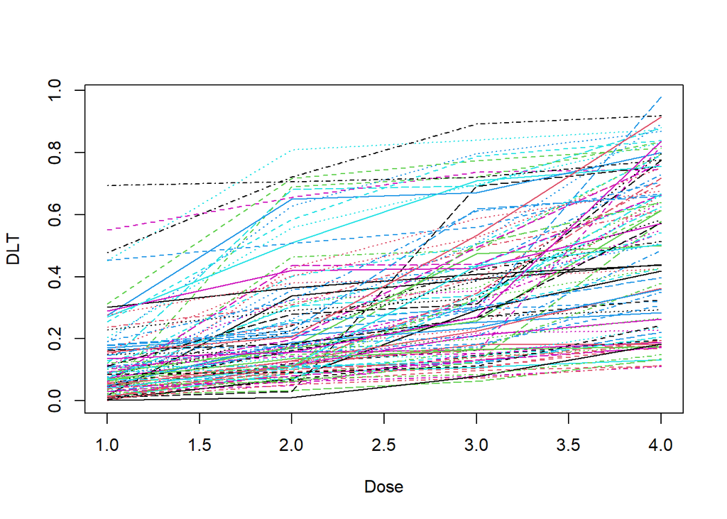

```r
#Assignment 1 for Advanced Clinical Trials;
library(ggplot2)
#Question 1: Generate 100 dose-toxicity curves using the CLertant and O'Quigley Method

#Set number of doses, number of simulations, and the MTD
random_dosetox_curves <- function(ndose = 4, nsim = 100, mtd = 0.2){
  #Assign number of doses
  doses <- ndose

  #Generate Dataframe doses X simulations to export later
  sims <- data.frame(matrix(nrow = nsim, ncol = doses + 1))
  mtdfin <- vector("numeric")

  #Create a function that exports one set of possible DLT values
  sim1 <- function(J = doses){
    #Identify the mtd for this case
    mtddose <- floor(runif(1, 1, (doses + 1)))
    #Sample from a random Beta
    m <- rbeta(1, max(J - mtddose, 0.5), 1)
    #Assign the upper bound for DLT probabilities
    b <- mtd + (1 - mtd) * m
    #Generate the random uniform DLTs of doses under that upper bound
    probs <- sort(runif(J, 0, b))
    #Idetify the randomly generated MTD
    found_mtd <- which.min(abs(probs - mtd))
      #suppressWarnings(max(max(which((probs - mtd) < 0)), 0))
    #Assign, Name, and Export the DLTs, Identified MTD, and true MTD dose
    sim1_res <- list(probs, found_mtd, mtddose)
    names(sim1_res) <- c("probs", "found_mtd", "mtddose")
    return(sim1_res)
  }

  #Set Starting value
  i <- 1

    while(i < nsim + 1){
      res <- sim1()
      #Create statement that if the found mtd is equal to the real mtd,
      #Assign those DLT values to the dataset; else return old dataset
      if(res$found_mtd == res$mtddose){
        sims[i,] <- c(res$probs, res$mtddose)
      }
      #Increase value of i only if the DLT values were assigned
      i <- ifelse(res$found_mtd == res$mtddose, i + 1, i)
    }
  #Return the dataset of all DLT probabilities that matched the criteria
  return(sims)
}


#Set seed to use throughout
set.seed(545)
curves <- random_dosetox_curves()

#Plot the DLT results found from the above function;
matplot(t(curves[, 1:4]), type = "l", xlab = "Dose", ylab = "DLT")
```

## Question 2

From the design, we properly select the MTD roughly 70% of the time in the initial simulated study. This is a very good PCS. The boxplot shows that although most curves perform well, they are not as well performing as the first model, with an average of 57.3%, and a median and range of 55.9% (1.5%, 100.0%).

```r
#Question 2: Nonparametric Benchmark
non_bench <- function(theta = 0.3, npat = 24, nsim = 5000, dltcuts = c(0.05, 0.15, 0.3, 0.5)){
  dltval <- vector("numeric")
  for(j in 1:nsim){
    #Set random uniform for a set of patients
    randlts <- runif(npat)
    #Set empty vectors
    simdlt <- vector("numeric")
    #Identify the minimum for each simulation
    for(i in 1:length(dltcuts)){
      simdlt[i] <- sum(randlts < dltcuts[i]) / npat
    }
    #Identify MTD
    dltval[j] <- which.min(abs(simdlt - theta))
  }
  #Return the MTD value
  return(dltval)
}

#Set Value to a table
table2 <- non_bench()

#Get number of times each dose is selected as mtd
doseselect <- c(sum(table2 == 1), sum(table2 == 2), sum(table2 == 3), sum(table2 == 4))/ (5000)
doseselect
```

```
## [1] 0.0008 0.1708 0.6914 0.1370
```

```r
1 - 4 * (abs(0.05 - 0.3) * doseselect[1] + abs(0.15 - 0.3) * doseselect[2] + abs(0.3 - 0.3) * doseselect[3] + abs(0.5 - 0.3) * doseselect[4]) /
      (abs(0.05 - 0.3) + abs(0.15 - 0.3) + abs(0.3 - 0.3) + abs(0.5 - 0.3))
```

```
## [1] 0.6452
```

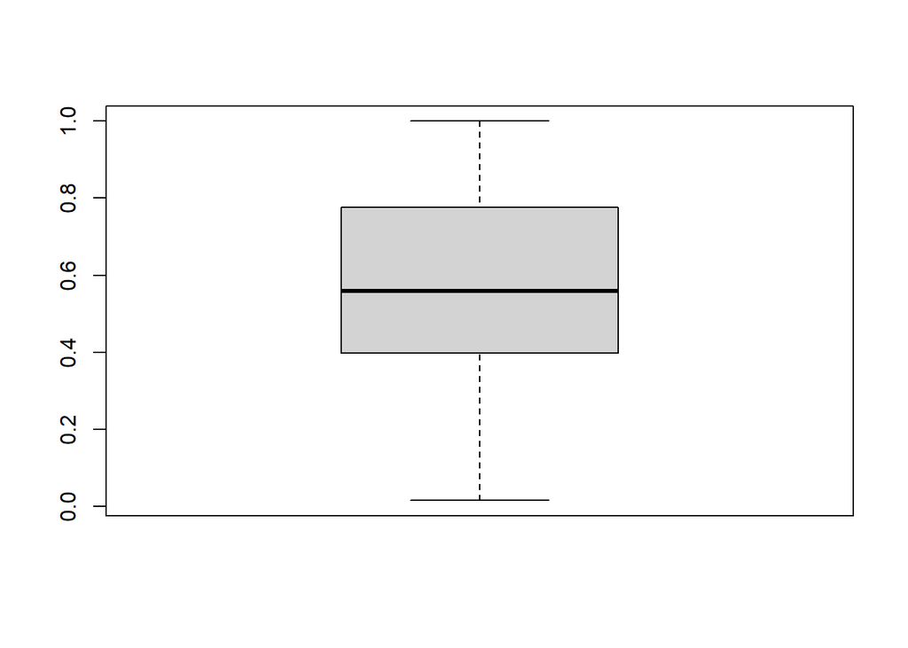

```r
#Set an empty matrix
vals <- matrix(nrow = 100, ncol = 5)
#Set i
i <- 1
#Replace the empty matrix with PCS values for each curve
for(i in 1:100){

  table2.2 <- non_bench(theta = 0.2, npat = 24, nsim = 1000, dltcuts = as.vector(curves[i, 1:4]))
  doseselect <- c(sum(table2.2 == 1), sum(table2.2 == 2), sum(table2.2 == 3), sum(table2.2 == 4)) / (1000)
  vals[i, ] <- c(doseselect, curves[i, 5])

}


#Isolate the true MTD values found
mtdvals <- vals[,5]
#Match those MTD values to the appropriate column
matchvals <- matrix(nrow = 100, ncol = 2)
for(i in 1:100){
  matchvals[i, 1] <- vals[i, mtdvals[i]]
  matchvals[i, 2] <- mtdvals[i]
}

#Plot the boxplot of the PCS values
boxplot(matchvals[, 1])
```

```r
#Summary statistics of PCS values
mean(matchvals[, 1])
```

```
## [1] 0.57285
```

```r
quantile(matchvals[, 1])
```

```
##      0%     25%     50%     75%    100%
## 0.01500 0.39975 0.55900 0.77700 1.00000
```

## Question 3

Below is the posterior curve with the red shaded region the current and the blue the target dlt rates. From these shaded areas, we would recommend to deescalate the dosage. However, this is not possible, but the dosage is not yet eliminated by the stopping rules. Thus we do not yet stop the trial despite there being no dose to deescalate to.

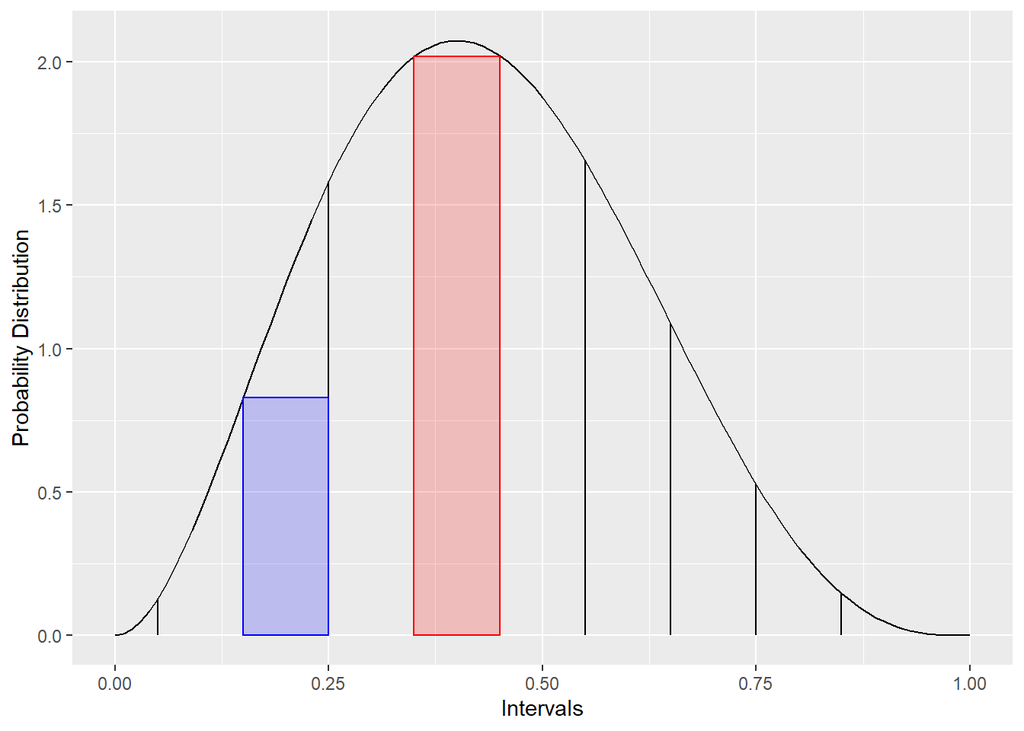

```r
#Question 3: Keyboard design
#Set Beta (1,1)
a <- 1
b <- 1
#Target DLT
theta <- 0.2
#Epsilons of intervals
ep <- 0.05
#Number of DLTs
succ <- 2
#Number of non-DLTs
fail <- 3
#Get the length of each key
keyleng <- 2 * ep

keyboard <- function(a =1, b = 1, theta = 0.2, ep = 0.05, succ = 2, fail = 3){
#Generate proper sequence of
intervals <- seq(from = ((theta - ep) %% keyleng),  to = 1, by = keyleng)
#Set empty vector to populate values, their names, and denote the true interval
val <- matrix(nrow = 1, ncol = length(intervals) - 1)
valnames <- matrix(nrow = 1, ncol = length(intervals) - 1)
trueint <- matrix(nrow = 1, ncol = length(intervals) - 1)

#Generate the probabilities from the beta distribution given our data
for(i in 1:(length(intervals) - 1)){
  val[i] <- pbeta(intervals[i + 1], a + succ, b + fail) - pbeta(intervals[i], a + succ, b + fail)
  valnames[i] <- c(paste0(intervals[i], ", ", intervals[i + 1]))
  trueint[i] <- (intervals[i] < theta & intervals[i + 1] > theta)
}

#Identify the target interval
targetint <- as.numeric(which(trueint == T))
colors <- c("Current" = "red", "Target" = "red")

#Plot the distribution
keyplot <- qplot(seq(0, 1, 0.01), geom = "blank") +
  stat_function(aes(1), fun = dbeta, colour = "black", n = 101,
                args = list(a + succ, b + fail)) +
  geom_segment(aes(x = intervals, y = 0, xend = intervals, yend = dbeta(intervals, a + succ, b + fail))) +
  #Highlight the highest probability area in red
  annotate('rect', xmin = intervals[which.max(val)], xmax = intervals[which.max(val) + 1],
                   ymin = 0, ymax = dbeta(seq(intervals[which.max(val)], intervals[which.max(val)], 0.01), a + succ, b + fail),
                   color = "red", alpha = 0.2, fill = "red") +
  #Highligh the target probability area in blue
  annotate('rect', xmin = intervals[targetint], xmax = intervals[targetint + 1],
           ymin = 0, ymax = dbeta(seq(intervals[targetint], intervals[targetint], 0.01), a + succ, b + fail),
           color = "blue", alpha = 0.2, fill = "blue") +
  labs(x = "Intervals",
       y = "Probability Distribution",
       color = "Legend")
  scale_color_manual(values = colors)

return(keyplot)

}

#Give results desired in assignment
keyboard()
```

## Question 4

```r
#Question 4: Compare 3 + 3, BOIN, and Keyboard
library(UBCRM)
library(BOIN)
set.seed(545)
latent_tox <- runif(24)
round(latent_tox, 3)
```

```
##  [1] 0.681 0.905 0.692 0.442 0.218 0.704 0.137 0.464 0.253 0.754 0.033 0.839
## [13] 0.751 0.646 0.569 0.712 0.488 0.618 0.796 0.179 0.467 0.930 0.018 0.441
```

```r
dlts <- c(0.05, 0.13, 0.25, 0.38)

#3 plus 3 design
set.seed(545)
s3p3 <- sim3p3(dlts, seed = 545)

#BOIN design
set.seed(545)
boinres <- get.oc(target = 0.25, p.true = dlts, ncohort = 8, cohortsize = 3, ntrial = 1, see = 545)
get.boundary(target = 0.25, ncohort = 8, cohortsize = 3)
```

```
## $lambda_e
## [1] 0.1968009
##
## $lambda_d
## [1] 0.2983922
##
## $boundary_tab
##
## Number of patients treated 3 6 9 12 15 18 21 24
## Escalate if # of DLT <=    0 1 1  2  2  3  4  4
## Deescalate if # of DLT >=  1 2 3  4  5  6  7  8
## Eliminate if # of DLT >=   3 4 5  6  7  8  9 10
##
## $full_boundary_tab
##
## Number of patients treated  1  2 3 4 5 6 7 8 9 10 11 12 13 14 15 16 17 18 19 20
## Escalate if # of DLT <=     0  0 0 0 0 1 1 1 1  1  2  2  2  2  2  3  3  3  3  3
## Deescalate if # of DLT >=   1  1 1 2 2 2 3 3 3  3  4  4  4  5  5  5  6  6  6  6
## Eliminate if # of DLT >=   NA NA 3 3 3 4 4 4 5  5  6  6  6  7  7  7  8  8  8  9
##
## Number of patients treated 21 22 23 24
## Escalate if # of DLT <=     4  4  4  4
## Deescalate if # of DLT >=   7  7  7  8
## Eliminate if # of DLT >=    9  9 10 10
##
## attr(,"class")
## [1] "boin"
```

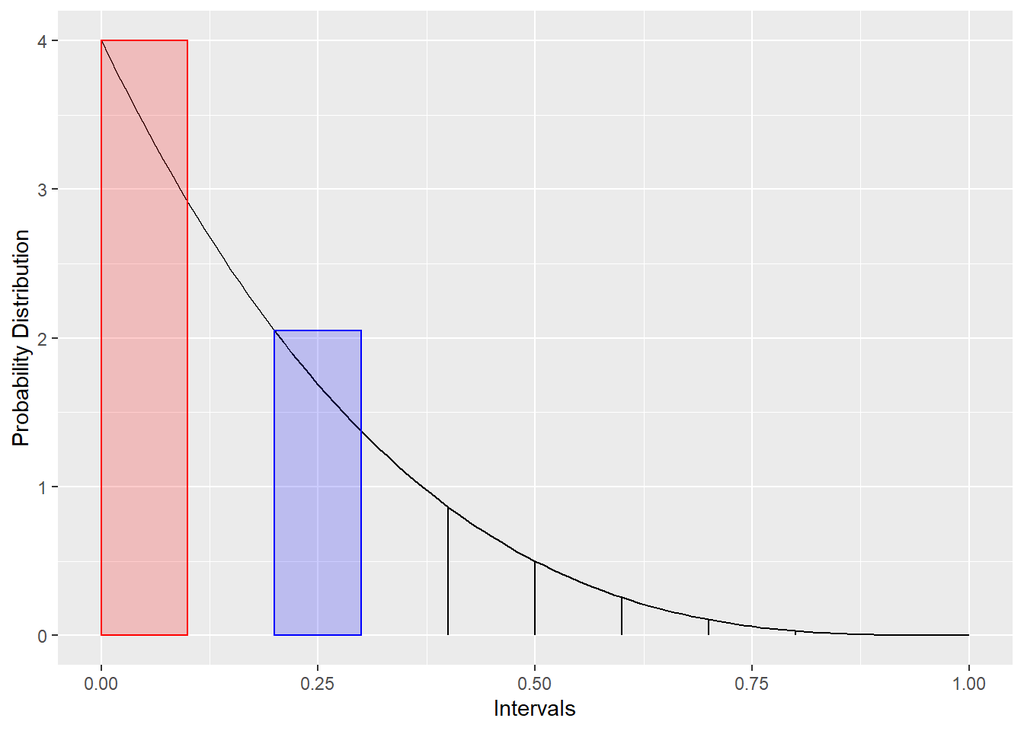

```r
#Keyboard
#Cohort 1 & 2 & 6
keyboard(a = 1, b = 1, theta = 0.25, ep = 0.05, succ = 0, fail = 3)
```

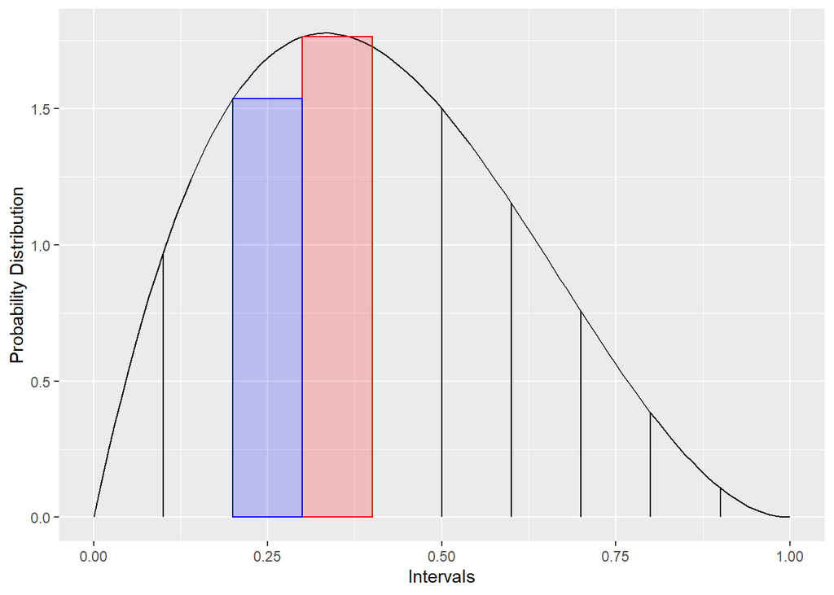

```r
#Cohort 3
keyboard(a = 1, b = 1, theta = 0.25, ep = 0.05, succ = 1, fail = 2)
```

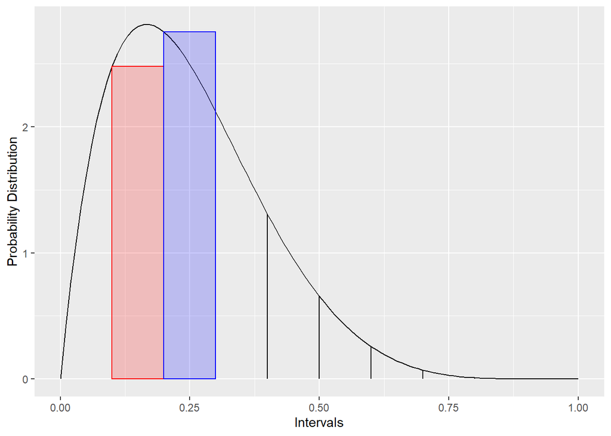

```r
#Cohort 4 & 5 & 7
keyboard(a = 1, b = 1, theta = 0.25, ep = 0.05, succ = 1, fail = 5)
```

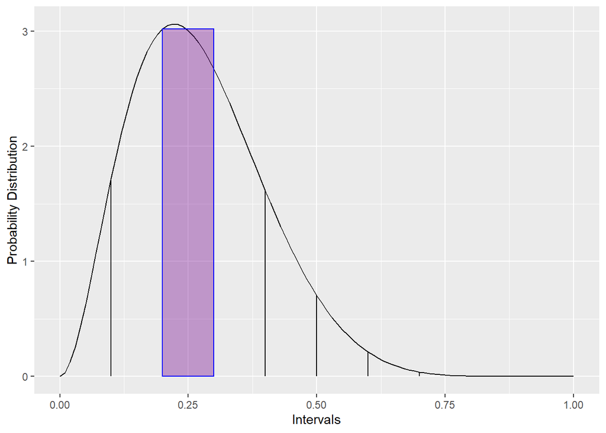

```r
#Final Allocation
keyboard(a = 1, b = 1, theta = 0.25, ep = 0.05, succ = 2, fail = 7)
```

## Question 5

```r
#Question 5: i3 + 3 design

#Create i3 + 3 function
i33 <- function(mtd = 0.3, ep = 0.05, n = 3, ncohort = 8, dltprobs = c(0.05, 0.15, 0.3, 0.5)){
  #Set upper and lower bounds of the interval
  lbmtd <- mtd - ep
  upmtd <- mtd + ep
  #Set initial dose level
  dose <- 1
  #Create empty vectors to fill in
  dltall <- vector("numeric")
  dosevec <- vector("numeric")
  for(i in 1:ncohort){
    #Generate number of random values
    x <- runif(n)
    #Decide if those random values are greater than the DLT cutoff
    dlt <- (x < dltprobs[dose])
    #Get a vector of the dose level
    dosevals <- rep(dose, n)
    #Add new values to vectors
    dltall <- c(dltall, dlt)
    dosevec <- c(dosevec, dosevals)
    #Set value of dlt over mtd
    dltmtdrat <- sum(dltall[dosevec == dose])/length(dltall[dosevec == dose])
    #Set value of dlt - 1 over mtd
    dltmtdratm1 <- (sum(dltall[dosevec == dose]) - 1)/length(dltall[dosevec == dose])
  #Create conditional statement as to what the next dose level should be
  if(dltmtdrat < lbmtd){
      dose <- min(dose + 1, length(dltprobs))
    } else if (lbmtd <= dltmtdrat & dltmtdrat <= upmtd){
      dose <- dose
    } else if (upmtd < dltmtdrat & dltmtdratm1 < lbmtd){
      dose <- dose
    } else {dose <- max(dose - 1, 1)}

  }
  #Return dataframe as output
  return(as.data.frame(cbind(dltall, dosevec, dose)))
}

set.seed(545)
#Get final dosages
table5 <- replicate(5000, i33()$dose)
#Identify how often we are choosing those doses
doseselect <- c(sum(table5 == 1), sum(table5 == 2), sum(table5 == 3), sum(table5 == 4))/ (24 * 5000)
doseselect
```

```
## [1] 0.0100 0.1954 0.5432 0.2514
```

```r
#Set an empty matrix
vals <- matrix(nrow = 100, ncol = 5)

#Set i
i <- 1
#Use the curves to get PCS estimates;
for(i in 1:100){
  table5.2 <- replicate(1000, i33(mtd = 0.2, n = 3, ncohort = 8, dltprobs = as.vector(curves[i, 1:4]))$dose)
  doseselect <- c(sum(table5.2 == 1), sum(table5.2 == 2), sum(table5.2 == 3), sum(table5.2 == 4))/ (24 * 1000)
  vals[i, 1:5] <- c(doseselect, curves[i, 5])
}

vals
```

```
##         [,1]  [,2]  [,3]  [,4] [,5]
##   [1,] 0.400 0.499 0.081 0.020    2
##   [2,] 0.041 0.083 0.245 0.631    4
##   [3,] 0.379 0.501 0.105 0.015    2
##   [4,] 0.422 0.519 0.057 0.002    2
##   [5,] 0.741 0.259 0.000 0.000    1
##   [6,] 0.118 0.246 0.253 0.383    4
##   [7,] 0.043 0.191 0.283 0.483    4
##   [8,] 0.106 0.349 0.455 0.090    2
##   [9,] 0.557 0.429 0.013 0.001    1
##  [10,] 0.026 0.146 0.303 0.525    4
##  [11,] 0.014 0.078 0.184 0.724    4
##  [12,] 0.998 0.002 0.000 0.000    1
##  [13,] 0.254 0.285 0.308 0.153    2
##  [14,] 0.752 0.198 0.046 0.004    1
```

[output cut: 86 more lines]

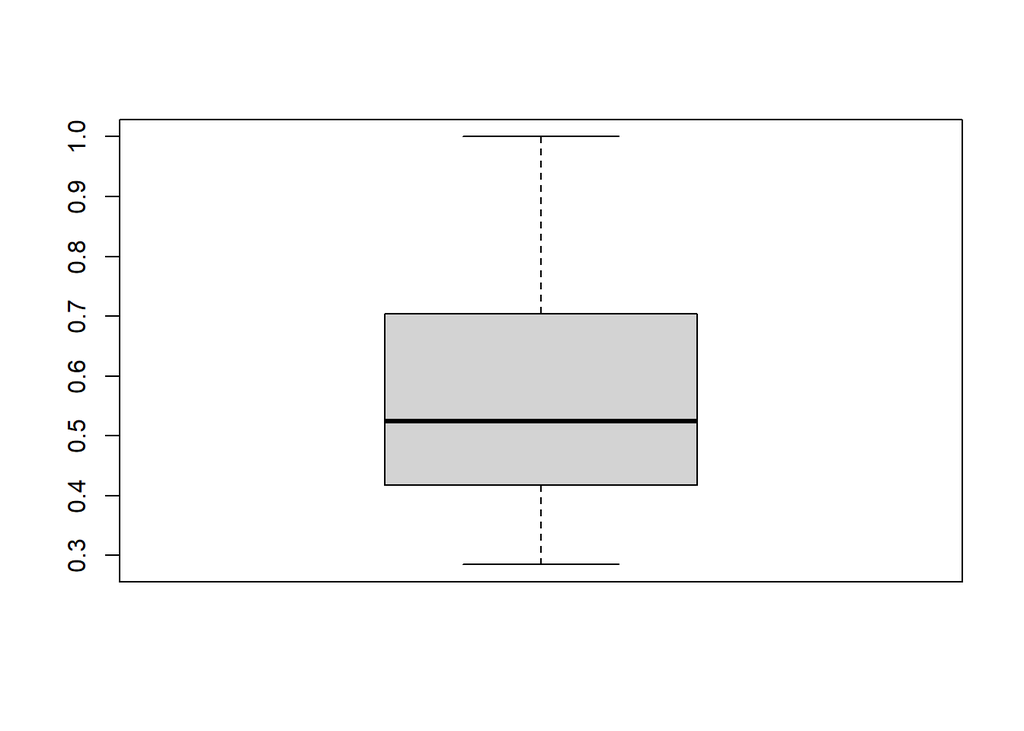

```r
#Isolate the true MTD values found
mtdvals <- vals[,5]
#Match those MTD values to the appropriate column
matchvals <- matrix(nrow = 100, ncol = 2)
for(i in 1:100){
  matchvals[i, 1] <- vals[i, mtdvals[i]]
  matchvals[i, 2] <- mtdvals[i]
}

#Plot the boxplot of the PCS values
boxplot(matchvals[, 1], subset = matchvals[, 2])
```

```r
#Summary statistics of PCS values
mean(matchvals[, 1])
```

```
## [1] 0.56703
```

```r
quantile(matchvals[, 1])
```

```
##      0%     25%     50%     75%    100%
## 0.28500 0.41850 0.52450 0.69675 1.00000
```